# Import libraries and obtain the data

```python
import numpy as np
import pandas as pd
import matplotlib.pyplot as plt
import seaborn as sns

import pathlib

from sklearn.metrics import confusion_matrix, classification_report, precision_recall_curve
import tensorflow as tf
from tensorflow import keras
from tensorflow.keras import layers
from tensorflow.keras.utils import image_dataset_from_directory
```

```python
# This should point to the small dataset of the Kaggle Dogs vs Cats competition that was created in a previous notebook
data_folder = pathlib.Path('../datasets/kaggle_dogs_vs_cats_small')

train_dataset = image_dataset_from_directory(
    data_folder / "train",
    image_size=(180, 180),
    batch_size=16)
validation_dataset = image_dataset_from_directory(
    data_folder / "validation",
    image_size=(180, 180),
    batch_size=16)
test_dataset = image_dataset_from_directory(
    data_folder / "test",
    image_size=(180, 180),
    batch_size=16)
```

```
Found 2000 files belonging to 2 classes.
Found 1000 files belonging to 2 classes.
Found 2000 files belonging to 2 classes.
```

# EDA

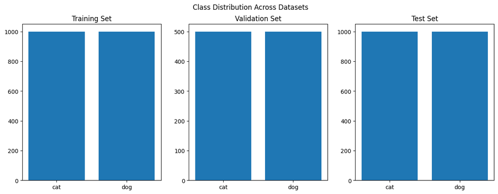

```python
# Get class names and counts for every class
class_names = train_dataset.class_names
train_counts = np.concatenate([y for x, y in train_dataset], axis=0)
val_counts = np.concatenate([y for x, y in validation_dataset], axis=0)
test_counts = np.concatenate([y for x, y in test_dataset], axis=0)

train_class_counts = [sum(train_counts == i) for i in range(len(class_names))]
val_class_counts = [sum(val_counts == i) for i in range(len(class_names))]
test_class_counts = [sum(test_counts == i) for i in range(len(class_names))]

# Plot class distribution
fig, ax = plt.subplots(1, 3, figsize=(15, 5))
ax[0].bar(class_names, train_class_counts)
ax[0].set_title('Training Set')
ax[1].bar(class_names, val_class_counts)
ax[1].set_title('Validation Set')
ax[2].bar(class_names, test_class_counts)
ax[2].set_title('Test Set')
plt.suptitle('Class Distribution Across Datasets')
plt.show()
```

It can be noticed that across all sets the classes are well-balanced.

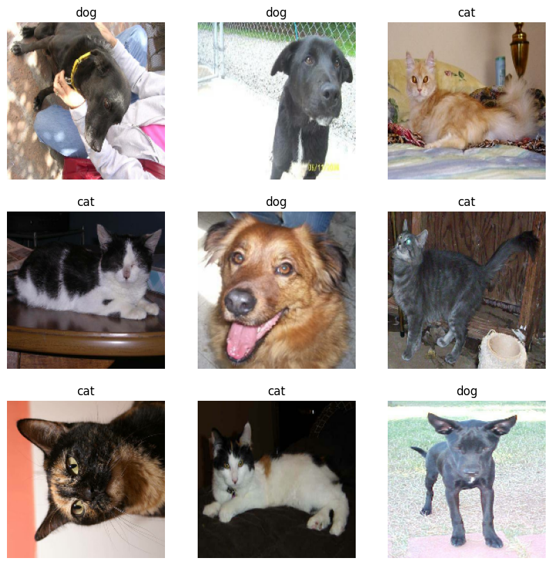

```python
plt.figure(figsize=(10, 10))
for images, labels in train_dataset.take(1):
    for i in range(9):
        ax = plt.subplot(3, 3, i + 1)
        plt.imshow(images[i].numpy().astype("uint8"))
        plt.title(class_names[labels[i]])
        plt.axis("off")
plt.show()
```

In addition, the training set contains a wide variety of cats and dogs not only in terms of species but also with different poses or angles. Also, I have to point out that in some images there is text, people, or other objects in the background.

# Models' training

## Custom CNN

```python
def make_custom_cnn_model(input_shape=(180, 180, 3)):
    inputs = keras.Input(shape=input_shape)
    x = layers.Rescaling(1./255)(inputs)
    x = layers.Conv2D(32, 3, activation="relu")(x)
    x = layers.MaxPooling2D(2)(x)
    x = layers.Conv2D(64, 3, activation="relu")(x)
    x = layers.MaxPooling2D(2)(x)
    x = layers.Conv2D(128, 3, activation="relu")(x)
    x = layers.MaxPooling2D(2)(x)
    x = layers.Flatten()(x)
    x = layers.Dense(256, activation="relu")(x)
    x = layers.Dropout(0.5)(x)
    outputs = layers.Dense(1, activation="sigmoid")(x)
    return keras.Model(inputs, outputs)

custom_cnn_model = make_custom_cnn_model()

custom_cnn_model.summary()
```

[output not shown]

```python
custom_cnn_model.compile(optimizer="adam",
              loss="binary_crossentropy",
              metrics=["accuracy"])

# Callbacks
callbacks = [
    keras.callbacks.ModelCheckpoint(
        filepath="./models/vanilla_cnn.keras",
        save_best_only=True, # to save the best version of the model
        monitor="val_loss")
]

# Tracking model's training
history_custom = custom_cnn_model.fit(
    train_dataset,
    epochs=30,
    validation_data=validation_dataset,
    callbacks=callbacks)
```

## Fine-Tuned VGG16

```python
# Load pre-trained VGG16
conv_base = keras.applications.VGG16(
    weights="imagenet",
    include_top=False,
    input_shape=(180, 180, 3))

# Build new model layers on top
inputs = keras.Input(shape=(180, 180, 3))
x = keras.applications.vgg16.preprocess_input(inputs)
x = conv_base(x)
x = layers.Flatten()(x)
x = layers.Dense(256, activation="relu")(x)
x = layers.Dropout(0.5)(x)
outputs = layers.Dense(1, activation="sigmoid")(x)
vgg_model = keras.Model(inputs, outputs)

vgg_model.summary()
```

[output not shown]

```python
# View of the model for Fine-tuning (just unfreeze top layers of base)
conv_base.trainable = True
for layer in conv_base.layers[:-4]:
    layer.trainable = False

vgg_model.summary()
```

[output not shown]

```python
vgg_model.compile(
    optimizer=keras.optimizers.RMSprop(learning_rate=1e-5),
    loss="binary_crossentropy",
    metrics=["accuracy"])

# Callbacks
callbacks = [
    keras.callbacks.ModelCheckpoint(
        filepath="./models/fine_tuned_vgg_model.keras",
        save_best_only=True, # to save the best version of the model
        monitor="val_loss")
]

# Tracking model's training
history_vgg = vgg_model.fit(
    train_dataset,
    epochs=30,
    validation_data=validation_dataset,
    callbacks=callbacks)
```

# Evaluating performance

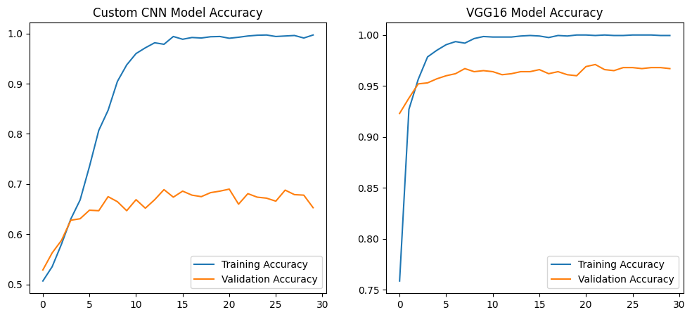

```python
# Plot training history (accuracy) for CNN and VGG16 model
plt.figure(figsize=(12, 5))
plt.subplot(1, 2, 1)
plt.plot(history_custom.history["accuracy"], label="Training Accuracy")
plt.plot(history_custom.history["val_accuracy"], label="Validation Accuracy")
plt.title("Custom CNN Model Accuracy")
plt.legend()

plt.subplot(1, 2, 2)
plt.plot(history_vgg.history["accuracy"], label="Training Accuracy")
plt.plot(history_vgg.history["val_accuracy"], label="Validation Accuracy")
plt.title("VGG16 Model Accuracy")
plt.legend()
plt.show()
```

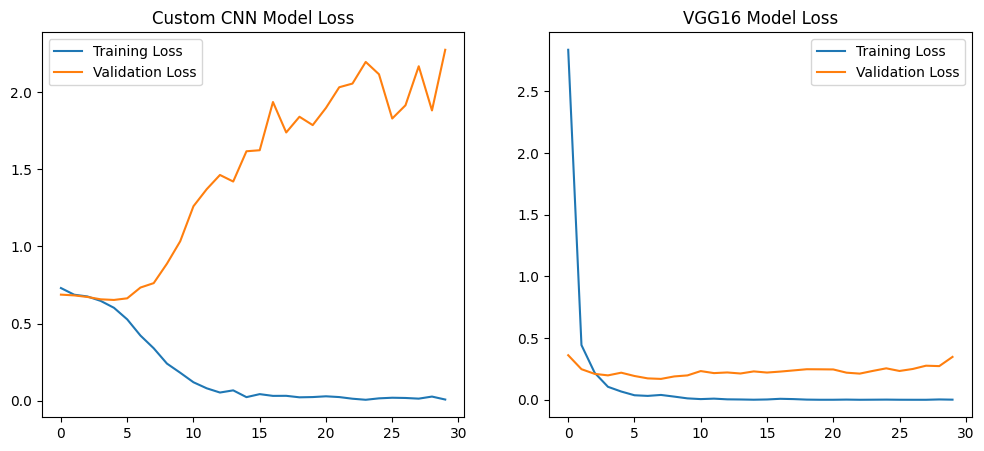

```python
# Plot training history (loss) for CNN and VGG16 model
plt.figure(figsize=(12, 5))
plt.subplot(1, 2, 1)
plt.plot(history_custom.history["loss"], label="Training Loss")
plt.plot(history_custom.history["val_loss"], label="Validation Loss")
plt.title("Custom CNN Model Loss")
plt.legend()

plt.subplot(1, 2, 2)
plt.plot(history_vgg.history["loss"], label="Training Loss")
plt.plot(history_vgg.history["val_loss"], label="Validation Loss")
plt.title("VGG16 Model Loss")
plt.legend()
plt.show()
```

Regarding loss:

- A clear gap between training and validation loss after around epoch 5 shows strong overfitting for the Custom CNN model.
- However, for VGG16 the difference in loss is relatively small, suggesting good generalization.

```python
# Saving the models (no need for retraining the models every time)
custom_cnn_model = keras.models.load_model("./models/vanilla_cnn.keras")
vgg_model = keras.models.load_model("./models/fine_tuned_vgg_model.keras")
```

```python
# Custom CNN model evaluation
custom_test_loss, custom_test_acc = custom_cnn_model.evaluate(test_dataset)
print(f"Custom Model Test Accuracy: {custom_test_acc:.3f}")
```

```
Custom Model Test Accuracy: 0.636
```

```python
# VGG16 model evaluation
vgg_test_loss, vgg_test_acc = vgg_model.evaluate(test_dataset)
print(f"VGG16 Model Test Accuracy: {vgg_test_acc:.3f}")
```

```
VGG16 Model Test Accuracy: 0.969
```

```python
# Making predictions
custom_preds = custom_cnn_model.predict(test_dataset)
vgg_preds = vgg_model.predict(test_dataset)

# Converting predictions into classes
custom_class_preds = (custom_preds > 0.5).astype("int32")
vgg_class_preds = (vgg_preds > 0.5).astype("int32")

# Get true labels
true_labels = np.concatenate([y for x, y in test_dataset], axis=0)
```

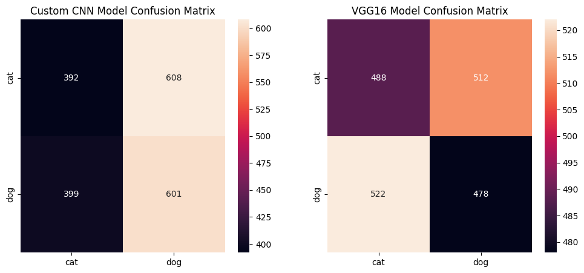

```python
# Calculate the confusion matrices
custom_cm = confusion_matrix(true_labels, custom_class_preds)
vgg_cm = confusion_matrix(true_labels, vgg_class_preds)

# Plot the confusion matrices
fig, ax = plt.subplots(1, 2, figsize=(12, 5))
sns.heatmap(custom_cm, annot=True, fmt="d", ax=ax[0],
            xticklabels=class_names, yticklabels=class_names)
ax[0].set_title("Custom CNN Model Confusion Matrix")
sns.heatmap(vgg_cm, annot=True, fmt="d", ax=ax[1],
            xticklabels=class_names, yticklabels=class_names)
ax[1].set_title("VGG16 Model Confusion Matrix")
plt.show()
```

```python
print("Custom CNN Model Classification Report:\n")
print(classification_report(true_labels, custom_class_preds, target_names=class_names))
```

```
Custom CNN Model Classification Report:

              precision    recall  f1-score   support

         cat       0.50      0.39      0.44      1000
         dog       0.50      0.60      0.54      1000

    accuracy                           0.50      2000
   macro avg       0.50      0.50      0.49      2000
weighted avg       0.50      0.50      0.49      2000
```

```python
print("VGG16 Model Classification Report:\n")
print(classification_report(true_labels, vgg_class_preds, target_names=class_names))
```

```
VGG16 Model Classification Report:

              precision    recall  f1-score   support

         cat       0.48      0.49      0.49      1000
         dog       0.48      0.48      0.48      1000

    accuracy                           0.48      2000
   macro avg       0.48      0.48      0.48      2000
weighted avg       0.48      0.48      0.48      2000
```

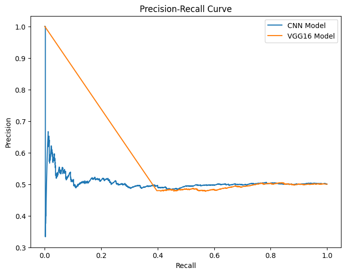

```python
# Precision-Recall curves
custom_precision, custom_recall, _ = precision_recall_curve(true_labels, custom_preds)
vgg_precision, vgg_recall, _ = precision_recall_curve(true_labels, vgg_preds)

plt.figure(figsize=(8, 6))
plt.plot(custom_recall, custom_precision, label="CNN Model")
plt.plot(vgg_recall, vgg_precision, label="VGG16 Model")
plt.xlabel("Recall")
plt.ylabel("Precision")
plt.title("Precision-Recall Curve")
plt.legend()
plt.show()
```